# IODS course project

# 5: Dimensionality reduction techniques

```r
date()
```

```
## [1] "Sun Dec 11 20:57:43 2022"
```

Libraries used:

```r
library(tidyverse)
library("GGally")
library(Hmisc)
```

```r
library(purrr)
library(tidyr)
library(ggplot2)
library(FactoMineR)
library(factoextra)
```

Read in data (reading it from url just to make sure it correct)

```r
human <- read.table("https://raw.githubusercontent.com/KimmoVehkalahti/Helsinki-Open-Data-Science/master/datasets/human2.txt", sep=",", header=TRUE)
```

## Explore the data

```r
str(human)
```

```
## 'data.frame':    155 obs. of  8 variables:
##  $ Edu2.FM  : num  1.007 0.997 0.983 0.989 0.969 ...
##  $ Labo.FM  : num  0.891 0.819 0.825 0.884 0.829 ...
##  $ Edu.Exp  : num  17.5 20.2 15.8 18.7 17.9 16.5 18.6 16.5 15.9 19.2 ...
##  $ Life.Exp : num  81.6 82.4 83 80.2 81.6 80.9 80.9 79.1 82 81.8 ...
##  $ GNI      : int  64992 42261 56431 44025 45435 43919 39568 52947 42155 32689 ...
##  $ Mat.Mor  : int  4 6 6 5 6 7 9 28 11 8 ...
##  $ Ado.Birth: num  7.8 12.1 1.9 5.1 6.2 3.8 8.2 31 14.5 25.3 ...
##  $ Parli.F  : num  39.6 30.5 28.5 38 36.9 36.9 19.9 19.4 28.2 31.4 ...
```

The data contains 155 rows and 8 variables. It contains 6 numerical variables and 2 integer variables.

Variables include: “Edu2.FM” = ratio of Female and Male populations with secondary education in each country “Labo.FM” = ratio of labor force participation of females and males in each country “Edu.Exp” = Expected years of schooling “Life.Exp” = Life expectancy at birth “GNI” = Gross National Income per capita “Mat.Mor” = Maternal mortality ratio “Ado.Birth” = Adolescent birth rate “Parli.F” = Percetange of female representatives in parliament

```r
summary(human)
```

```
##     Edu2.FM          Labo.FM          Edu.Exp         Life.Exp
##  Min.   :0.1717   Min.   :0.1857   Min.   : 5.40   Min.   :49.00
##  1st Qu.:0.7264   1st Qu.:0.5984   1st Qu.:11.25   1st Qu.:66.30
##  Median :0.9375   Median :0.7535   Median :13.50   Median :74.20
##  Mean   :0.8529   Mean   :0.7074   Mean   :13.18   Mean   :71.65
##  3rd Qu.:0.9968   3rd Qu.:0.8535   3rd Qu.:15.20   3rd Qu.:77.25
##  Max.   :1.4967   Max.   :1.0380   Max.   :20.20   Max.   :83.50
##       GNI            Mat.Mor         Ado.Birth         Parli.F
##  Min.   :   581   Min.   :   1.0   Min.   :  0.60   Min.   : 0.00
##  1st Qu.:  4198   1st Qu.:  11.5   1st Qu.: 12.65   1st Qu.:12.40
##  Median : 12040   Median :  49.0   Median : 33.60   Median :19.30
##  Mean   : 17628   Mean   : 149.1   Mean   : 47.16   Mean   :20.91
##  3rd Qu.: 24512   3rd Qu.: 190.0   3rd Qu.: 71.95   3rd Qu.:27.95
##  Max.   :123124   Max.   :1100.0   Max.   :204.80   Max.   :57.50
```

Variables have quite different scales as they relate to different things. Let’s look at them by plotting them. I will try hist.data.frame from “Hmisc”-package (never used before). I used 30 bins (nclass-argument).

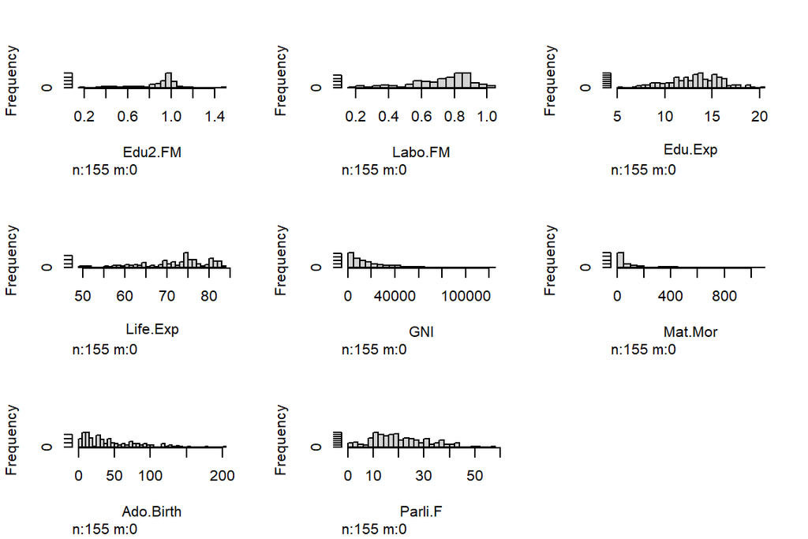

```r
hist.data.frame(human, nclass =30)
```

Quite many of the variables are skewed (Labo.Fm, GNI, Ado.Birth, Parli.F, Mat.Mor). I am not sure if we can say that for example Edu2.FM is normally distributed based on this graph. Also Life.Exp is maybe a bit skewed? (THIS PRINTIG WORKED NORMALLY IN RSTUDIO BUT RMARKDOWN PRINTS EVERYTHING SMALL, NOT SURE WHY THIS IS AND CAN’T GET PICTURE BIGGER)

Let’s use ggpairs to get more overview on the data and see some correlations between them (I hope that the correlation used in ggpairs is applicable for this kind of data set).

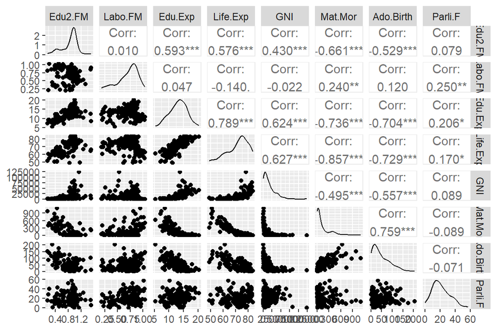

```r
ggpairs(human)
```

For reading purposes, here are the variable names again:

“Edu2.FM” = ratio of Female and Male populations with secondary education in each country “Labo.FM” = ratio of labor force participation of females and males in each country “Edu.Exp” = Expected years of schooling “Life.Exp” = Life expectancy at birth “GNI” = Gross National Income per capita “Mat.Mor” = Maternal mortality ratio “Ado.Birth” = Adolescent birth rate “Parli.F” = Percetange of female representatives in parliament

and so forth. The strongest correlation seems to be between Mat.Mpr and Life.Exp (-0.857). Some other strong ones are Edu.Exp with Life.Exp (0.789), Edu.Exp with Mat.Mor (-0.736), Math.Mor with Ado.Birth (0.759) and Life.Exp with Ado.Birth (-0.729).

## PCA

### Non-standardized

Let’s then turn to PCA. First let’s perform PCA on raw, unstandardised data.

```r
pca_human <- prcomp(human)
summary(pca_human)
```

```
## Importance of components:
##                              PC1      PC2   PC3   PC4   PC5   PC6    PC7    PC8
## Standard deviation     1.854e+04 185.5219 25.19 11.45 3.766 1.566 0.1912 0.1591
## Proportion of Variance 9.999e-01   0.0001  0.00  0.00 0.000 0.000 0.0000 0.0000
## Cumulative Proportion  9.999e-01   1.0000  1.00  1.00 1.000 1.000 1.0000 1.0000
```

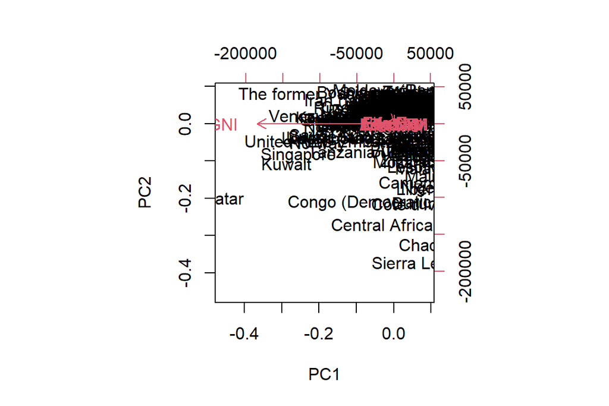

```r
# draw a biplot of the principal component representation and the original variables
biplot(pca_human, choices = 1:2)
```

Let’s edit the biplot with ideas from Exercise5.

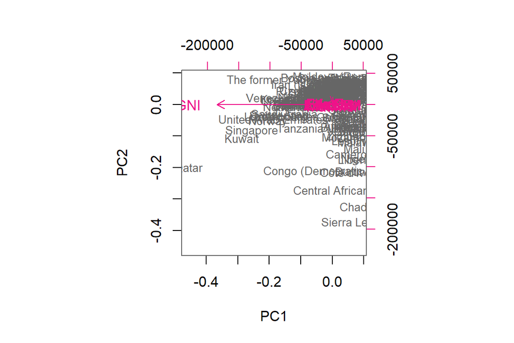

```r
biplot(pca_human, choices = 1:2, cex = c(0.8,1), col = c("grey40", "deeppink2"))
```

### Standardized

Let’s then standardize the variables to see if they make more sense.

```r
human_std <- scale(human)
pca_human_std <- prcomp(human_std)
summary(pca_human_std)
```

```
## Importance of components:
##                           PC1    PC2     PC3     PC4     PC5     PC6     PC7
## Standard deviation     2.0708 1.1397 0.87505 0.77886 0.66196 0.53631 0.45900
## Proportion of Variance 0.5361 0.1624 0.09571 0.07583 0.05477 0.03595 0.02634
## Cumulative Proportion  0.5361 0.6984 0.79413 0.86996 0.92473 0.96069 0.98702
##                            PC8
## Standard deviation     0.32224
## Proportion of Variance 0.01298
## Cumulative Proportion  1.00000
```

These results are much more undestandable. PC1 seems to be explaining 53,6% of the variance in the data set, PC2 16,2 and PC3 around 10. With these three PC:s 79% of the variance is explained in the data set. One can also see standard deviation for each component. They seem to be in decreasing order. These are apparently square root of the eigenvalue

Bi-plotting the stanrdardized data set.

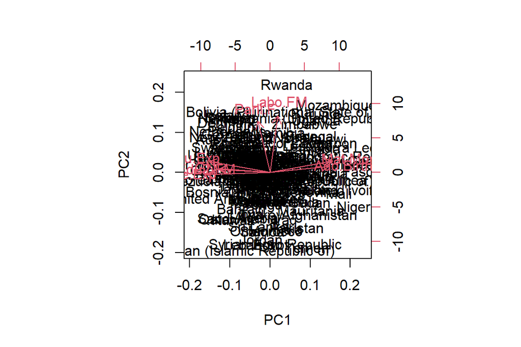

```r
biplot(pca_human_std, choices = 1:2)
```

Edit Bi-plot

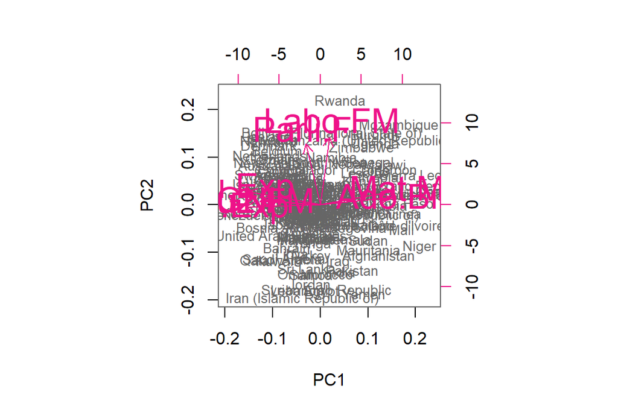

```r
biplot(pca_human_std, choices = 1:2, cex = c(0.8,2), col = c("grey40", "deeppink2"))
```

This gives us much clearer picture. But let’s edit it a bit futher before analyzing it.

Let’s print how much each componenent captures variance in proportions of variance.

```r
#save pca
s <- summary(pca_human_std)

# rounded percentanges of variance captured by each PC
pca_pr <- round(1*s$importance[2, ], digits = 5)
pca_pr
```

```
##     PC1     PC2     PC3     PC4     PC5     PC6     PC7     PC8
## 0.53605 0.16237 0.09571 0.07583 0.05477 0.03595 0.02634 0.01298
```

Let’s only print how much each component captures variance in percentages.

```r
pca_pr_2 <- round(100*s$importance[2, ], digits = 1)
pca_pr_2
```

```
##  PC1  PC2  PC3  PC4  PC5  PC6  PC7  PC8
## 53.6 16.2  9.6  7.6  5.5  3.6  2.6  1.3
```

Let’s plot again, with percentages of variance captured.

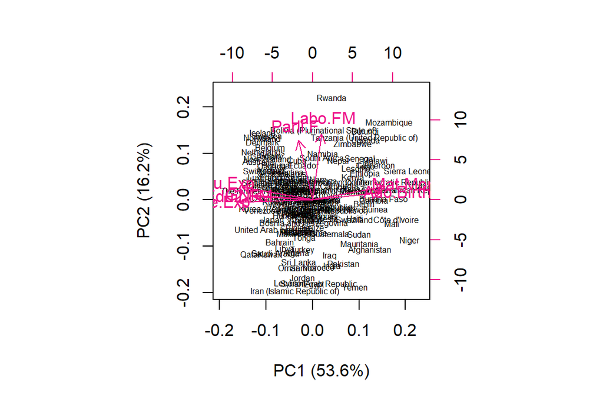

```r
pc_lab <- paste0(names(pca_pr_2), " (", pca_pr_2, "%)")
biplot(pca_human_std, cex = c(0.5, 1), col = c("black", "deeppink2"), xlab = pc_lab[1], ylab = pc_lab[2])
```

The left countries are quite grouped together. They share similar values relating to expected years of schooling, life expectancy at birth, ratio of Female and Male populations with secondary education in each country and Gross National Income per capita. These countries seem to be quite rich countries. The countries on the left are thus countries with higher education years, lower maternal mortality rates etc. Countries on the right share especially high maternal mortality ratio and adolecent birth rate.

On the vertical axis, which does not explain as much variance as PC1, countries differiante especially related to Percentage of female representatives in parliament and with ratio of labor force participation of females and males in each country. Countries on the top have higher values in those variables than the countries in the bottom of the plot. One can see that countries in the top include countries from several different continents. In the bottom the countries seem to more come from the Middle east. These countries have fewer female representatives in parliament and lower ratio of labor force participation of females and males in each country.